# TEAMBULDING ACTIVITY IN VALENCIA

HELMSBRISCOE

JULY 3RD 2019

## **PROPOSED ACTIVITY**

### **RAFT BUILDING PROJECT**

After receiving some basic tuition in navigation, the participants must pass the Robinson Crusoe Raft Navigation Test. Then they will be given a raft design kit and be assigned a budget to purchase everything they need to build a raft. Finally, all the teams will compete in a regatta with their creations.

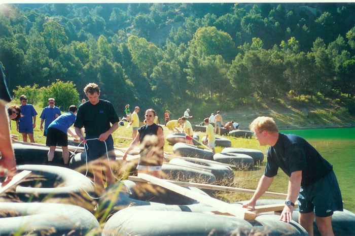

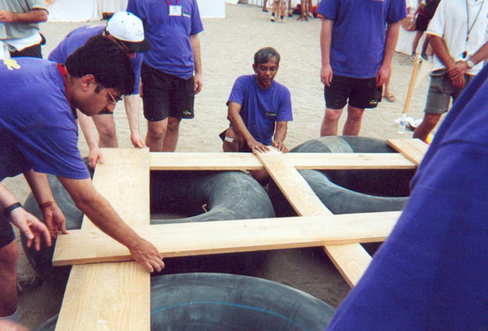

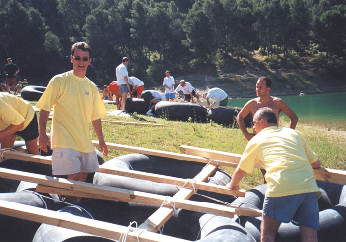

The cost will be: Flat rate of €1500 Rate per person €121

*To these rates we will need to add the rent of the venue and transfer*

** The price of our event includes**:

- Telephone conversation in order to ascertain the requirements of the client.
- Reservation of the agreed venue.
- Setting up and dismantling of the entire event.
- Transport of necessary materials to the site of the event.
- Use of all the materials necessary to the event.
- Team fees (Project manager and monitors).
- Qualified, uniformed personnel.
- Setting up of 9m2 (3x3) canvas tents (where possible).
- Certain decorative elements depending on the event, such as banners and cordons.
- Transport and expenses of our personnel.
- Prize giving ceremony.
- Medal for each member of the three winning teams.

## **SUGESTED VENUE FOR THE ACTIVITY: MASIA ALDAMAR**

- **Location** 25 minutes drive from Valencia city centre
- **Facilities** Gardens and Pool

**Masía Aldamar** is a spectacular country estate, dedicated to orange growing, just 15km from the centre of Valencia and a mere 5 minutes from the airport. The estate dates from the(**15th century** and still maintains its original patios, wineries, oil press and chapel. The unique spaces offer the chance to hold one-of-a-kind events: the chapel for civil ceremonies, an ancient cobbled patio, a large capacity main hall and a hundred-year-old garden with the traditional pool that is a feature of Valencia ́s orange growing activity. There is also a second winery where the estate’s original wine-making activity has been revived.

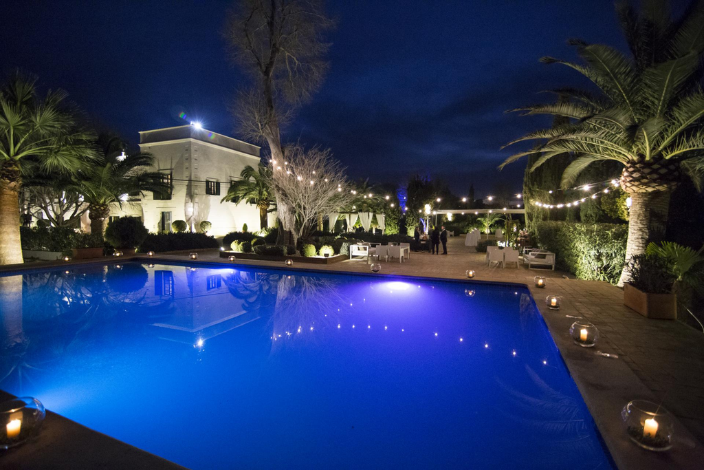

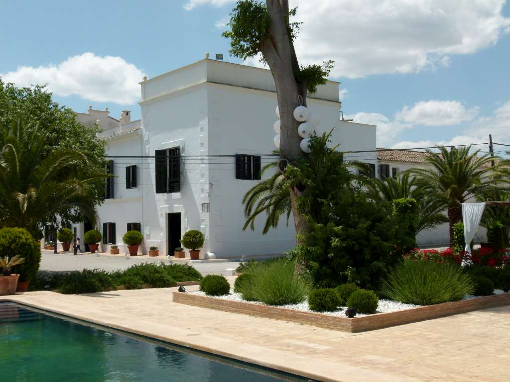

Hire cost of the venue minimum charge €2400 Open bar 2 hours during the activity including soft drinks, beer and water. Rate per person from €18

*Transfer is needed to arrive the venue - the cost of 54 seater coach 4 hours at disposal for the activity starting at 430€*

## Terms & Conditions

- Rates valid for 2019.
- For a group of minimum 50 pax.
- Cutting Edge Events management fee including in the detailed rates
- VAT included.
- No reservation has been done. Availability upon request.